# 2 Sucesiones de números reales

## 2.1 Ejercicios Resueltos

Para la realización de esta práctica se requieren los siguientes paquetes:

```julia
using SymPy  # Para el cálculo simbólico de límites.
using Plots  # Para el dibujo de gráficas.
using Makie # Para obtener gráficos interactivos.
using LaTeXStrings  # Para usar código LaTeX en los gráficos.
```

**Ejercicio 2.1** Dar los 10 primeros términos de las siguientes sucesiones:

1. $(2n+1)_{n=1}^\infty$

   **Ayuda**

   Definir una función para el término general y aplicar la función a los naturales de 1 a 10 usando [compresiones de arrays](https://aprendeconalf.es/manual-julia/tipos-datos-compuestos.html#comprensi%C3%B3n-de-arrays).

   **Solución**

   ```julia
   a(n) = 2n + 1
   println([a(n) for n = 1:10])
   ```

   ```
   [3, 5, 7, 9, 11, 13, 15, 17, 19, 21]
   ```

2. $\left(\frac{1}{n}\right)_{n=1}^\infty$

   **Solución**

   ```julia
   # Como reales
   a(n) = 1 / n
   println([a(n) for n = 1:10])
   # Como racionales
   a(n) = 1//n
   println([a(n) for n = 1:10])
   ```

   ```
   [1.0, 0.5, 0.3333333333333333, 0.25, 0.2, 0.16666666666666666, 0.14285714285714285, 0.125, 0.1111111111111111, 0.1]
   Rational{Int64}[1, 1//2, 1//3, 1//4, 1//5, 1//6, 1//7, 1//8, 1//9, 1//10]
   ```

3. $\left((-1)^n\right)_{n=1}^\infty$

   **Solución**

   ```julia
   a(n) = (-1)^n
   println([a(n) for n = 1:10])
   ```

   ```
   [-1, 1, -1, 1, -1, 1, -1, 1, -1, 1]
   ```

4. $\left(\left(1+\frac{1}{n}\right)^n\right)_{n=1}^\infty$

   **Solución**

   ```julia
   a(n) = (1 + 1 / n)^n
   println([a(n) for n = 1:10])
   ```

   ```
   [2.0, 2.25, 2.3703703703703702, 2.44140625, 2.4883199999999994, 2.5216263717421135, 2.546499697040712, 2.565784513950348, 2.5811747917131984, 2.5937424601000023]
   ```

5. $a_1=1$ y $a_{n+1}=\sqrt{1+a_n}$ $\forall n\in\mathbb{N}$

   **Solución**

   ```julia
   a(n) = n == 1 ? 1 : sqrt(1+a(n-1))
   println([a(n) for n = 1:10])
   ```

   ```
   Real[1, 1.4142135623730951, 1.5537739740300374, 1.5980531824786175, 1.6118477541252516, 1.616121206508117, 1.6174427985273905, 1.617851290609675, 1.6179775309347393, 1.6180165422314876]
   ```

**Ejercicio 2.2** Dibujar en una gráfica los 50 primeros términos de las siguientes sucesiones y deducir si son convergentes o no. En el caso de que sean convergentes, dar un valor aproximado de su límite.

**Ayuda**

Definir una función para el término general y aplicar la función a los naturales de 1 a 50 usando compresiones de arrays como en el ejercicio anterior. Después usar la función [`scatter`](https://aprendeconalf.es/manual-julia/graficos.html#a%C3%B1adir-puntos-a-una-gr%C3%A1fica) del paquete `Plots`, o bien la función [`scatter`](https://aprendeconalf.es/manual-julia/graficos.html#diagrama-de-puntos) del paquete `Makie`, para dibujar el array de términos.

1. $\left(\frac{n}{4n+2}\right)_{n=1}^\infty$

   **Solución**

   **Plots**

   ```julia
   using Plots
   a(n) = n / (4n + 2)
   scatter([a(n) for n = 1:50], legend=false)
   ```

[figure not shown]

   **Makie**

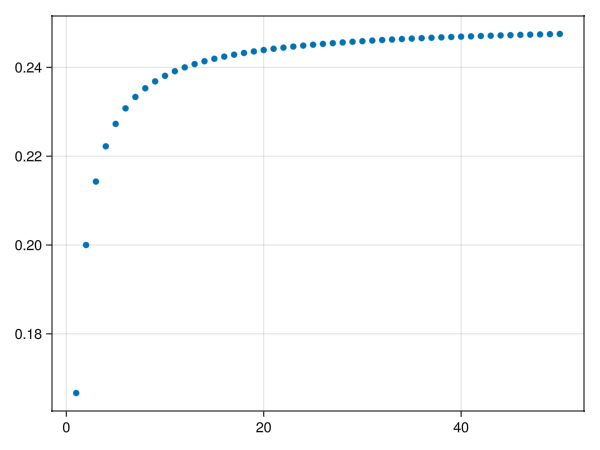

   ```julia
   using GLMakie
   a(n) = n / (4n + 2)
   Makie.scatter([a(n) for n = 1:50])
   ```

   **Solución**

   **Plots**

   ```julia
   using Plots
   a(n) = 2^n / (4n + 2)
   scatter([a(n) for n = 1:50], legend=false)
   ```

[figure not shown]

   **Makie**

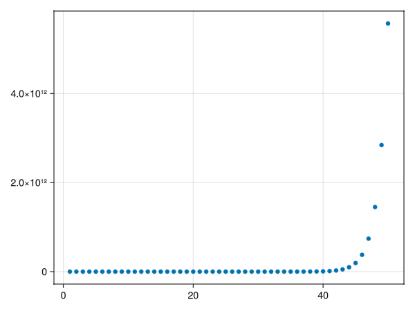

   ```julia
   using GLMakie
   a(n) = 2^n / (4n + 2)
   Makie.scatter([a(n) for n = 1:50])
   ```

   La sucesión diverge.
3. $\left(\frac{(-1)^n}{n}\right)_{n=1}^\infty$

   **Solución**

   **Plots**

   ```julia
   using Plots
   a(n) = (-1)^n / n
   scatter([a(n) for n = 1:50], legend=false)
   ```

[figure not shown]

   **Makie**

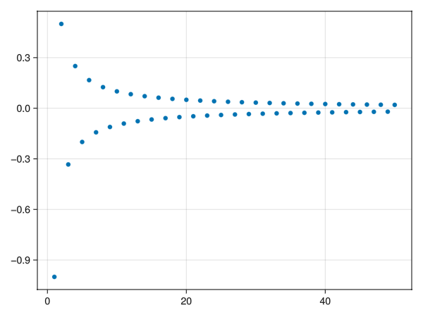

   ```julia
   using GLMakie
   a(n) = (-1)^n / n
   Makie.scatter([a(n) for n = 1:50])
   ```

   La sucesión converge al $0$.
4. $\left(\left(1+\frac{1}{n}\right)^n\right)_{n=1}^\infty$

   **Solución**

   **Plots**

   ```julia
   using Plots
   a(n) = (1 + 1 / n)^n
   scatter([a(n) for n = 1:50], legend=false)
   ```

[figure not shown]

   **Makie**

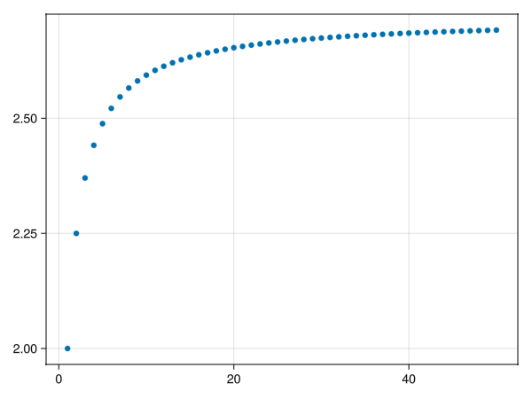

   ```julia
   using GLMakie
   a(n) = (1 + 1 / n)^n
   Makie.scatter([a(n) for n = 1:50])
   ```

   La sucesión converge aproximadamente a $2.7$.
5. $a_1 = 0.5$ y $a_{n+1}=\frac{3}{2+a_n}$ $\forall n\in\mathbb{N}$

   **Solución**

   **Plots**

   ```julia
   using Plots
   a(n) =  n == 1 ? 0.5 : 3/(2+a(n-1))
   scatter([a(n) for n = 1:50], legend=false)
   ```

[figure not shown]

   **Makie**

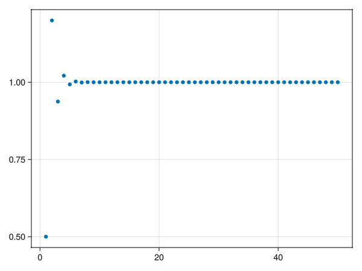

   ```julia
   using GLMakie
   a(n) = n == 1 ? 0.5 : 3/(2+a(n-1))
   Makie.scatter([a(n) for n = 1:50])
   ```

   La sucesión converge aproximadamente a $1$.

**Ejercicio 2.3** Calcular el límite, si existe, de las siguiente sucesiones.

1. $\left(\frac{1}{n}\right)_{n=1}^\infty$

   **Ayuda**

   Definir una función para el término general y usar la función [`limit`](https://docs.juliahub.com/SymPy/KzewI/1.0.31/Tutorial/calculus/#Limits-1) del paquete `SymPy` para calcular el límite de la sucesión.

   **Solución**

   ```julia
   using SymPy
   @syms n  # Declaración de la variable simbólica n.
   a(n) = 1/n
   limit(a(n), n=>oo)
   ```

   $0$

2. $\left((-1)^n\right)_{n=1}^\infty$

   **Solución**

   ```julia
   @syms n
   a(n) = (-1)^n
   limit(a(n), n=>oo)
   ```

   $\text{NaN}$

3. $\left(\left(1+\frac{1}{n}\right)^n\right)_{n=1}^\infty$

   **Solución**

   ```julia
   @syms n
   a(n) = (1 + 1 / n)^n
   limit(a(n), n=>oo)
   ```

   $e$

**Ejercicio 2.4** En el siglo III A.C [Arquímedes](https://es.wikipedia.org/wiki/Arqu%C3%ADmedes) usó el [método por agotamiento](https://es.wikipedia.org/wiki/M%C3%A9todo_por_agotamiento) para calcular el área encerrada por una circunferencia (y de paso el valor de $\pi$). La idea consiste en inscribir la circunferencia en polígonos regulares con un número de lados cada vez mayor.

[figure not shown]

Aproximación del área de una circunferencia mediante polígonos regulares

El área de estos polígonos puede calcularse fácilmente descomponiendo los polígonos regulares en triángulos como en el siguiente ejemplo.

[figure not shown]

Descomposición de un hexágono en triángulos

En el caso de los polígonos inscritos dentro de la circunferencia, como dos de los lados siempre coinciden con el radio de la circunferencia $r$, el perímetro del polígon de $n$ lados puede calcularse con la fórmula

$$p_n = 2nr\operatorname{sen}\left(\frac{\pi}{n}\right)$$

y el área puede calcularse con la fórmula

$$a_n = \frac{1}{2}nr^2\operatorname{sen}\left(\frac{2\pi}{n}\right).$$

1. Calcular el perímetro de los polígonos de $10^i$ lados, para $i=1,\ldots, 6$ tomando $r=1$.

   **Solución**

   ```julia
   p(n) = 2n*sin(pi/n)
   println([p(10^i) for i = 1:6])
   ```

   ```
   [6.180339887498948, 6.282151815625658, 6.283174971759127, 6.28318520382533, 6.283185306146043, 6.283185307169251]
   ```

2. Calcular el área de los polígonos de $10^i$ lados, para $i=1,\ldots, 6$ tomando $r=1$.

   **Solución**

   ```julia
   a(n) = n*sin(2*pi/n)/2
   println([a(10^i) for i = 1:6])
   ```

   ```
   [2.938926261462366, 3.1395259764656687, 3.1415719827794755, 3.141592446881286, 3.141592651522708, 3.1415926535691225]
   ```

3. Dibujar con los primeros 50 términos de la sucesión de los perímetros de los polígonos tomando $r=1$.

   **Solución**

   **Plots**

   ```julia
   using Plots
   a(n) = 2n*sin(pi/n)
   scatter([a(n) for n = 1:50], legend=false)
   ```

[figure not shown]

   **Makie**

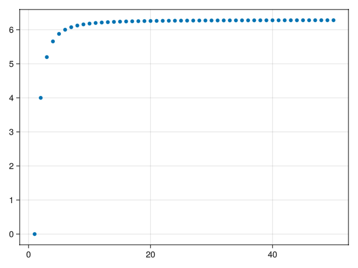

   ```julia
   using GLMakie
   a(n) = 2n*sin(pi/n)
   Makie.scatter([a(n) for n = 1:50])
   ```

4. Dibujar con los primeros 50 términos de la sucesión de las areas de los polígonos tomando $r=1$.

   **Solución**

   **Plots**

   ```julia
   using Plots
   a(n) = n*sin(2*pi/n)/2
   scatter([a(n) for n = 1:50], legend=false)
   ```

[figure not shown]

   **Makie**

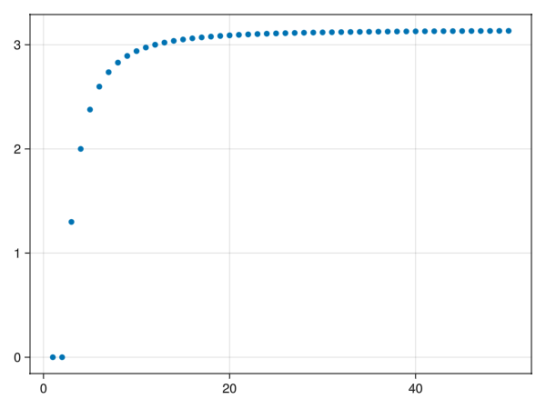

   ```julia
   using GLMakie
   a(n) = n*sin(2*pi/n)/2
   Makie.scatter([a(n) for n = 1:50])
   ```

5. Calcular el límite de la sucesión de los perímetros de los polígonos tomando $r=1$.

   **Solución**

   ```julia
   using SymPy
   @syms n
   a(n) = 2n*sin(PI/n)  # Para cálculo simbólico es mejor utilizar la constante simbólica PI en lugar de pi.
   limit(a(n), n=>oo)
   ```

   $2 \pi$

6. Usando el resultado anterior, calcular el perímetro del círculo de radio $r$.

   **Solución**

   ```julia
   using SymPy
   @syms n, r
   a(n) = 2n*r*sin(PI/n)
   limit(a(n), n=>oo)
   ```

   $2 \pi r$

7. Calcular el límite de la sucesión de las areas de los polígonos tomando $r=1$.

   **Solución**

   ```julia
   using SymPy
   @syms n
   a(n) = n*sin(2*PI/n)/2
   limit(a(n), n=>oo)
   ```

   $\pi$

8. Usando el resultado anterior, calcular el area del círculo de radio $r$.

   **Solución**

   ```julia
   using SymPy
   @syms n, r
   a(n) = n*r^2*sin(2*PI/n)/2
   limit(a(n), n=>oo)
   ```

   $\pi r^{2}$

**Ejercicio 2.5** Dada la sucesión $a_1=1$ y $a_{n+1}=1+\frac{1}{a_n}$ $\forall n\in\mathbb{N}$, se pide:

1. Dibujar la gráfica de los 10 primeros términos de la sucesión. ¿Es una sucesión monótona?

   **Solución**

   **Plots**

   ```julia
   using Plots
   a(n) =  n == 1 ? 1 : 1 + 1 / a(n-1)
   scatter([a(n) for n = 1:10], legend=false)
   ```

[figure not shown]

   **Makie**

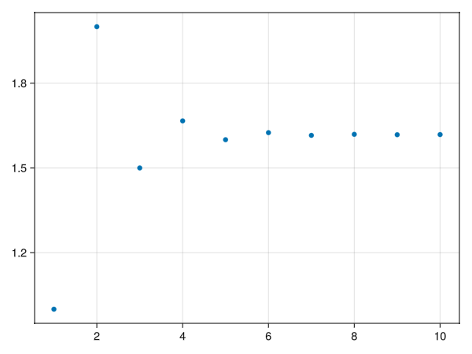

   ```julia
   using GLMakie
   a(n) = n == 1 ? 1 : 1 + 1 / a(n-1)
   Makie.scatter([a(n) for n = 1:10])
   ```

   La sucesión no es monótona.
2. Dibujar la gráfica de los 5 primeros términos de las subsucesiones con los términos pares e impares. ¿Son monótonas?

   **Solución**

   **Plots**

   ```julia
   using Plots, LaTeXStrings
   a(n) =  n == 1 ? 1 : 1 + 1 / a(n-1)
   Plots.scatter([a(2i-1) for i=1:5], label = L"$a_{2n-1}$")
   Plots.scatter!([a(2i) for i=1:5], label = L"$a_{2n}$")
   ```

[figure not shown]

   **Makie**

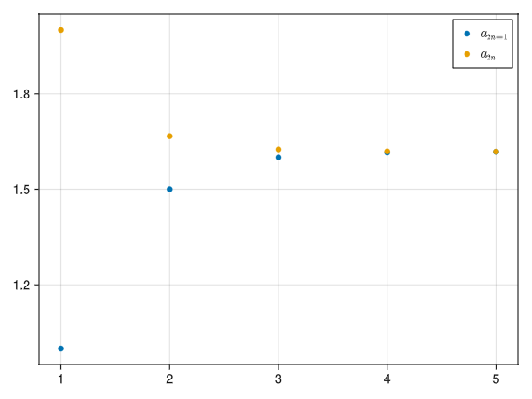

   ```julia
   using GLMakie
   a(n) = n == 1 ? 1 : 1 + 1 / a(n-1)
   fig, ax = Makie.scatter([a(2i-1) for i = 1:5], label = L"$a_{2n-1}$" )
   Makie.scatter!(ax,[a(2i) for i=1:5], label = L"$a_{2n}$")
   axislegend()
   fig
   ```

   La sucesión de los términos impares es creciente y la de los pares es decreciente.

## 2.2 Ejercicios propuestos

**Ejercicio 2.6** Calcular el décimo término de la sucesión $\left(\frac{3n^2+n}{6n^2-1}\right)_{n=1}^\infty$.

🎁

**Ejercicio 2.7** Calcular los 10 primeros términos de la sucesión $\left(\frac{3n^2+n}{6n^2-1}\right)_{n=1}^\infty$ y averiguar hacia dónde converge.

No converge

1.5

0.5

1

0

**Ejercicio 2.8** ¿Cuál de las siguientes gráficas corresponde a la sucesión $a_1=3$ y $a_{n+1}=\sqrt{2a_n}$ $\forall n\in\mathbb{N}$.

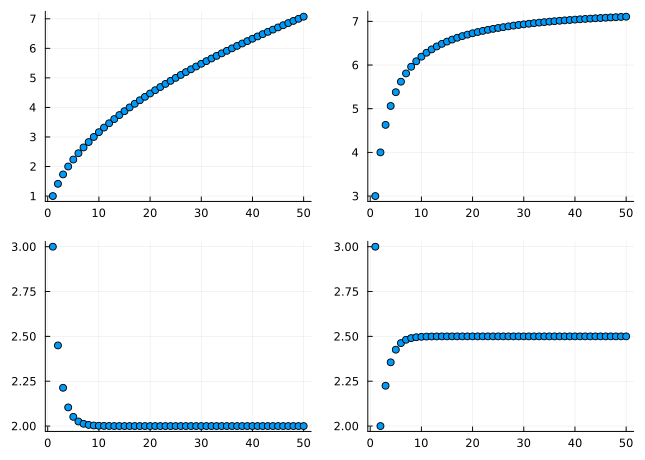

**Ejercicio 2.9** A la vista de la gráfica de los 20 primeros términos de la sucesión $\left(\frac{2^n}{n!}\right)_{n=1}^\infty$, ¿crees que la sucesión converge?

Yes

No

**Ejercicio 2.10** A la vista de la gráfica de los 10 primeros términos de la sucesión $\left(\frac{n^n}{n!}\right)_{n=1}^\infty$, ¿crees que la sucesión converge?

Yes

No

**Ejercicio 2.11** A la vista de la gráfica de los 20 primeros términos de la sucesión dada por $a_1=1$ y $a_{n+1}=\sqrt{a_n+2}$ $\forall n\in \mathbb{N}$, ¿crees que la sucesión converge?

Yes

No

**Ejercicio 2.12** ¿Cuál es el límite de la sucesión $\left(\left(1+\frac{2}{n}\right)^n\right)_{n=1}^\infty$

🎁